# Multispectral water stress monitoring

Flueckiger_Rubens

2025-12-09

# 1 Introduction

To accomplish the task of predicting the fLUE for new, unseen data given a training set, I have decided to use a random forest model. However, the main focus in this report exercise does not lie in the modelling step, but more on the step of filling missing values in the training and testing set. Many models can predict an outcome given a set of predictors only if the predictor set does not contain any missing data. The resulting model can thereby only be as good as its underlying data. Imputing missing data by filling missing values, without *disturbing* the original data as much as possible, is thereby a crucial pre-processing step in machine learning. In this report exercise I will include an imputation and an upsampling preprocessing step to the training set to model fLUE values based on multispectral informations from satellites.

# 2 Packages

```r
library(caret)
library(dplyr)
library(ggplot2)
library(RColorBrewer)
library(recipes)
library(rnaturalearth)
library(rnaturalearthdata)
library(sf)
library(themis)
```

# 3 Datasets

In a first step we will load in the training and test set as well as a data frame containing informations about the stations used to retrieve multispectral informations.

```r
df_test <- readr::read_csv("../data/MSWM/competition2025_testing_data.csv")
df_train <- readr::read_csv("../data/MSWM/competition2025_training_data.csv")
df_sites <- readr::read_csv("../data/MSWM/fdk_site_info.csv")
```

## 3.1 Data location

In a next step we can display the spatial distribution of all sites used in the training and testing set. To accomplish this task, we can use the `unique()` function to determine all unique sites inside the training and testing site. Additionally we will check if all sites are included inside the site-information dataset.

```r
# Select all unique sites from test and training dataset in site info data
idx_site_test <- which(df_sites$sitename %in% df_test$site)
idx_site_train <- which(df_sites$sitename %in% df_train$site)

# Combine all sites into one list and select only these sites
idx_sites <- unique(c(idx_site_test, idx_site_train))
relevant_sites <- df_sites[idx_sites, ]

# Select all unique sites in test and training dataset
sites_test <- unique(df_test$site)
sites_train <- unique(df_train$site)

# Combine into one list
sites_all <- c(sites_train, sites_test)

# Select all sites without information
sites_all[!(sites_all %in% relevant_sites$sitename)]
```

```
## [1] "AR-Vir" "AU-Ade" "AU-Fog" "AU-Wom" "DE-Spw" "SN-Dhr" "US-Wi4" "DK-NuF"
```

As one can see, not every site is included in the site-information dataset. Thereby I have included a dataset which includes information about longitude and latitude of the missing sites (these informations can be retrieved [here](https://fluxnet.org/sites/site-list-and-pages/)).

> **Note:**
> - The site `DK-NuF` is located in Nuuk, Greenland. Therefore, the site uses the abbreviation *GL* instead of *DK* (the station can be found under `GL-NuF`)
> - As I will only display the location of all used stations, the dataset containing the missing sites only contains information about its location (longitude and latitude). To combine both datasets more easily, I filled the remaining columns given in the site-information dataset with `NA`.

```r
# Load information about missing sites
add_sites <- readr::read_csv("../data/MSWM/fdk_additional_sites.csv")

# Combine additional sites and present sites into one dataset
relevant_sites <- rbind(relevant_sites, add_sites)
```

Given the locations of the missing and present sites, we can now plot the spatial distribution of the locations.

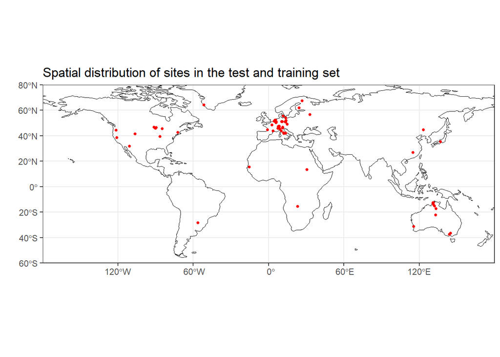

Figure 1: Locations of all sites used in the training and test site.

```r
# get coast outline
coast <- rnaturalearth::ne_coastline(scale = 110, returnclass = "sf")

ggplot() +

  #Plot coastline
  geom_sf(data = coast, colour = "black", size = 0.2) +

  # set extent in longitude and latitude
  # to draw map strictly bounded by the specified extent
  coord_sf(ylim = c(-60, 80), expand = FALSE) +

  # plot points on map
  geom_point(
    data = relevant_sites,
    aes(x = lon, y = lat),
    color = "red",
    size = 1
  ) +

  # Label adjustments
  labs(
    x = "", y = "",
    title = "Spatial distribution of sites in the test and training set"
  ) +

  theme_bw()
```

As one can see, the most sites are located either in Europe, the US or in Australia.

# 4 Impute data

The training set contains over 100’000 observations. To reduce the run-time of the imputation process, I have decided to reduce the input dataset to randomly selected 10’000 observations. One could improve this step by splitting the training dataset into n different folds according to a metric (this could be spatial informations or based on predictors) and impute the training set according to these folds. This approach might generate more realistic imputed values, as observations nearer to each other have a high chance to be similar to each other (this approach would be similar to the spatial upsampling report exercise). To explain on why I have decided agianst using this approach, I will plot the result of a 5-fold classification spatial distribution based on spatial information.

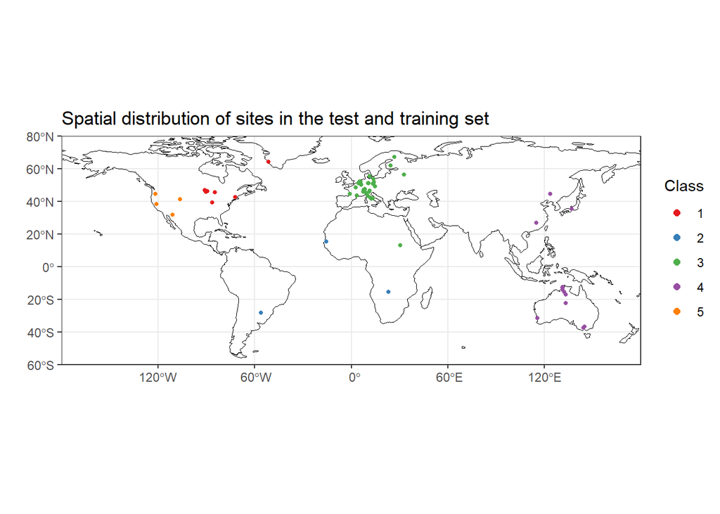

Figure 2: Distribution of sites used in the training and test set when classified according to its spatial location.

```r
# Create a five fold cluster
set.seed(109)
cluster <- kmeans(
  relevant_sites[, c("lon", "lat")],
  centers = 5
)

# Add cluster classes to dataset
relevant_sites$class <- as.factor(cluster$cluster)

ggplot() +

  #Plot coastline
  geom_sf(data = coast, colour = "black", size = 0.2) +

  # set extent in longitude and latitude
  # to draw map strictly bounded by the specified extent
  coord_sf(ylim = c(-60, 80), expand = FALSE) +

  # plot points on map
  geom_point(
    data = relevant_sites,
    aes(x = lon, y = lat, color = class),
    size = 1
  ) +

  # Colour points according to their class
  scale_color_manual(
    values = brewer.pal(n = 5, "Set1"),
    name = "Class"
  ) +

  # Enlarge point size of legend
  guides(color = guide_legend(override.aes = list(size = 2))) +

  # Label adjustments
  labs(
    x = "", y = "",
    title = "Spatial distribution of sites in the test and training set"
  ) +

  theme_bw()
```

A classification based on predictor variables is also impossible, as there is no predictor in the training *and* test set, which does not contain any missing values. I thereby decided to use 10’000 randomly selected sites to use as a baseline to impute the missing data in the training and testing set. Important to note here is that the subset should contain every vegetation type included in the training set to appropriately predict the outcome.

```r
# Create random sample of 10'000 sites
set.seed(155)
idx <- sample(1:length(df_train$site), 10000)

# Check if all sites are included in subset
subset_sites <- unique(df_train[idx, "vegtype"])$vegtype
vegtypes <- unique(df_train$vegtype)
vegtypes[!(vegtypes %in% subset_sites)]
```

```
## character(0)
```

As one can see from the output, the random sampling of 10’000 observations does contain every vegetation type of the original data. We thereby can start to set a recipe with the `recipe()` function from the `recipes` package. To impute the missing data I will use a KNN (5 neighbours) approach with the `step_impute_knn()` function. Additionally I will normalise the data to *fake* the data as little as possible using the `step_center()` and the `step_scale()` function over all predictors. With the `prep()` function, all steps defined are being ‘trained’ such that they can be applied on the data set using the `bake()` function.

> **Note:**

> As this step might take a while, I saved the outcomming imputed dataset and set the operation inside an `if(FALSE)` statement.

```r
if(FALSE){

  # Set recipe
  pp_train <- recipe( # Set function to fill NA values
    flue ~ NR_B1 + NR_B2 + NR_B3 + NR_B4 + NR_B5 + NR_B6 + NR_B7 + LST + t2m_era5 + ssrd_era5 + pcwd_era5 + vegtype,
    data = df_train # df containing these columns
  ) |>
    step_impute_knn(all_predictors(), neighbors = 5) |> # KNN impute
    step_center(all_numeric_predictors()) |> # Normalise data
    step_scale(all_numeric_predictors()) # Normalise data

  # 'Train' recipe
  trained <- prep(
    pp_train, # recipe
    training = df_train[idx, ], # 'Train' on reduced training set
    verbose = TRUE # Return processing status
  )

  # Apply 'trained' recipe on training data to impute NA values
  train_data <- bake(trained, new_data = df_train)

  # Add necessary columns back to df
  data_train <- train_data |> mutate(
    site = df_train$site, # Site
    date = df_train$date, # Date of sample
    is_flue_drought = df_train$is_flue_drought, # Logical flue status
    cluster = df_train$cluster # Clusters
  )

  # Save imputed training file
  readr::write_csv(data_train, file = "../data/MSWM/mswm_train_imputed")
}
```

Since the testing set contains vegetation types outside the training set we additionally need to add a `step_dummy()` function to convert the categorical variable into a dummy-numerical format to handle the additional variable. Other than that, the step above can be repeated for the test set.

```r
if(FALSE){

  # Set recipe
  pp_test <- recipe( # Set function to fill NA values
    flue ~ NR_B1 + NR_B2 + NR_B3 + NR_B4 + NR_B5 + NR_B6 + NR_B7 + LST + t2m_era5 + ssrd_era5 + pcwd_era5 + vegtype,
    data = df_train # df containing these columns
  ) |>
    step_dummy(vegtype, keep_original_cols = TRUE) |> # test contains additional vegtypes
    step_impute_knn(all_predictors(), neighbors = 5) |> # KNN imputation
    step_center(all_numeric_predictors()) |> # Normalise data
    step_scale(all_numeric_predictors()) # Normalise data

  # 'Train' recipe
  trained_test <- prep(
    pp_test, # recipe
    training = df_train[idx, ], # Train on reduced training set
    verbose = TRUE # Return processing status
  )

  # Apply 'trained' recipe on test set to fill NA values
  test_data <- bake(trained_test, new_data = df_test)

  data_test <- test_data[, c(1:12)] |> mutate( # Select only necessary columns
    site = df_test$site, # Add site column
    date = df_test$date, # Add date column
    is_flue_drought = df_test$is_flue_drought, # Add drought status column
    cluster = df_test$cluster # Add cluster column
  )

  # Save imputed test file
  readr::write_csv(data_test, file = "../data/MSWM/mswm_test_imputed")
}
```

# 5 Upsample

With the imputation step done, we can now start to overemphasize fLUE values of drought situations. First however, we need to load the previously imputed datasets.

```r
# Load imputed files
df_test_imp <- readr::read_csv("../data/MSWM/mswm_test_imputed")
df_train_imp <- readr::read_csv("../data/MSWM/mswm_train_imputed")
```

Next we need to make sure, that conditional variable `is_flue_drought` does not contain any missing values. As we now that `is_flue_drought` will take the value `TRUE` if the fLUE value is below 1 and `FALSE` if not, we can simply impute missing values manually.

```r
# Check for NA values for drought status
flue_idx_na <- which(is.na(df_train_imp$is_flue_drought) == T)

# Impute drought status column
# Note: flue < 1 = TRUE (it is a drought)
for(i in 1:length(flue_idx_na)){
  ifelse(
    df_train_imp[flue_idx_na[i], "flue"] < 1,
    df_train_imp[flue_idx_na[i], "is_flue_drought"] <- TRUE,
    df_train_imp[flue_idx_na[i], "is_flue_drought"] <- FALSE
  )
}
```

To compare the ratio of `TRUE` to `FALSE` values before and after upsampling the dataset, I will display the amount of `TRUE` and `FALSE` values in a table.

```r
# Distribution of drought and moist before upsampling
orig <- count(df_train_imp, is_flue_drought, name = "orig")

# Create table
knitr::kable(
  orig, # df
  align = "lc", # Information position
  caption = "Table 1: Amount of fLUE moist (FALSE) and drought (TRUE) observation", # Table caption
  col.names = c("is fLUE drought", "Original dataset") # Column names
)
```

Table 1: Amount of fLUE moist (FALSE) and drought (TRUE) observation

| is fLUE drought | Original dataset |
| --- | --- |
| FALSE | 84357 |
| TRUE | 24375 |

Before we can start to upscale `TRUE` values for `is_flue_drought`, we need to convert `is_flue_drought` into a factor format using the `as.factor()` function. Then we can set a recipe using `is_flue_drought` as the target. Using the `step_upsample()` function of the `themis` package we can now specify the final ratio of major to minor variable to be upsample to. I have set the final ratio to be at 0.5 (this means we have half as many `TRUE` values as `FALSE` values).

```r
# Change is_flue_drought values to factor format
df_train_imp_adj <- df_train_imp |> mutate(
  is_flue_drought = as.factor(is_flue_drought)
)

# upsampling recipe
pp_upsample <- recipe(
  is_flue_drought ~ ., # Set function
  data = df_train_imp_adj # df
) |> themis::step_upsample(
    is_flue_drought, # Column to consider
    over_ratio = 0.5 # Final ratio between major and minor class
) |> prep() # 'Train' recipe

# Apply 'trained' recipe
df_train_upsamp <- bake(pp_upsample, new_data = NULL)
```

Finally we can compare the amount before and after upsampling of `TRUE` and `FALSE` values.

```r
# Distribution of drought and not drought after upsampling
upsamp <- count(df_train_upsamp, is_flue_drought, name = "upsamp")

# Combine upsample and original ratio information
stat <- cbind(orig, upsamp)[, c(1, 2, 4)] # Only select relevant columns

# Create table
knitr::kable(
  stat, # df
  align = "lcc", # Information position
  caption = "Table 2: Comparing amount of fLUE moist (FALSE) and drought (TRUE) observation before and after upsampling", # Table caption
  col.names = c("is fLUE drought", "Original dataset", "Upsampled dataset") # Column names
)
```

Table 2: Comparing amount of fLUE moist (FALSE) and drought (TRUE) observation before and after upsampling

| is fLUE drought | Original dataset | Upsampled dataset |
| --- | --- | --- |
| FALSE | 84357 | 84357 |
| TRUE | 24375 | 42178 |

As one can see, we added about 20’000 `is_flue_drought = TRUE` values to the training set.

# 6 Modelling

Finally we can train a random forest model using the `caret` package.

```r
set.seed(155) # Set seed
folds <- caret::groupKFold(df_train_upsamp$flue, k = 5) # prepare folds

traincntrlParams <- caret::trainControl( # Set fold settings
  index = folds,
  method = "cv"
)
```

Then we can set the function to predict fLUE based on a predictor set. To convert the function into a caret-usable function, we need to convert the format using the `as.formula()` function.

```r
# Select predictors
predictors <- c(
  "NR_B1", "NR_B2", "NR_B3", "NR_B4", "NR_B5", "NR_B6", "NR_B7",
  "LST", "t2m_era5", "ssrd_era5", "pcwd_era5", "vegtype"
)

# Create string with all variables
fun_pred <- paste(
  c("flue ~", paste(predictors, collapse = " + ")),
  collapse = " "
)

# Convert into a caret-readable string
fun_pred <- formula(fun_pred)
```

Finally we can fit the model using the `ranger` method of `caret::train()`. To reduce runtime, I set `mtry` to 3 and `min.node.size` to 5, the default for a regression.

```r
mod_cv <- caret::train(
  fun_pred, # Model function
  data = df_train_upsamp, # training set
  method = "ranger", # Random Forest model
  trControl = traincntrlParams,
  tuneGrid = data.frame(
    .mtry = 3,
    .min.node.size = 5,
    .splitrule = "variance"
  )
)
```

Given the random forest model, we can now apply the model on the unseen test set.

```r
# Predict values
pred <- predict(
  mod_cv,
  newdata = df_test_imp
)
```

The resulting predictions will be saved for the competition.

As the test set does not contain the actual fLUE values, comparing predicted and observed is not possible. However, one could improve my results by considering more than 10’000 observations. Similar to the results from the LULC-exercise, one has to ask whether the benefits gained by considering a larger subset of training sites outweighs the drawbacks occurring through the longer runtime.